# Decorrelation-Based Feature Discovery: body_fat

Jose Tamez

2024-03-04

# 1 Effect of UPSTM-Based Decorrelation on Feature Discovery

### 1.0.1 Loading the libraries

```r
library("FRESA.CAD")
library(readxl)
library(igraph)
library(umap)
library(tsne)
library(entropy)
library(psych)
library(whitening)
library("vioplot")
library("rpart")

op <- par(no.readonly = TRUE)
pander::panderOptions('digits', 3)
pander::panderOptions('table.split.table', 400)
pander::panderOptions('keep.trailing.zeros',TRUE)
```

## 1.1 Material

Data Source https://www.kaggle.com/datasets/fedesoriano/body-fat-prediction-dataset

“Source The data were generously supplied by Dr. A. Garth Fisher who gave permission to freely distribute the data and use for non-commercial purposes.

Roger W. Johnson Department of Mathematics & Computer Science South Dakota School of Mines & Technology 501 East St. Joseph Street Rapid City, SD 57701

email address: rwjohnso@silver.sdsmt.edu web address: http://silver.sdsmt.edu/~rwjohnso”

## 1.2 The Data

```r
body_fat <- read.csv("~/GitHub/LatentBiomarkers/Data/BodyFat/BodyFat.csv", header=TRUE)

### Removing density as estimator
body_fat$Density <- NULL

#par(cex=0.5)
```

### 1.2.1 Standarize the names for the reporting

```r
studyName <- "Body_Fat"
dataframe <- body_fat
outcome <- "BodyFat"

thro <- 0.40
cexheat <- 0.75
loops  <- 100
```

## 1.3 Generaring the report

### 1.3.1 Libraries

Some libraries

```r
library(psych)
library(whitening)
library("vioplot")
library("rpart")
library(multiColl)
library(car)

source("C:/Users/jtame/Documents/GitHub/LatentBiomarkers/RMD/RepeatedLinearCV.R")
```

### 1.3.2 Data specs

```r
pander::pander(c(rows=nrow(dataframe),col=ncol(dataframe)-1))
```

| rows | col |
| --- | --- |
| 252 | 13 |

```r
varlist <- colnames(dataframe)
varlist <- varlist[varlist != outcome]

largeSet <- length(varlist) > 1500
```

### 1.3.3 Training and testing sets

```r
set.seed(1)
trainsamples <- sample(nrow(dataframe),3*nrow(dataframe)/4)

trainingset <- dataframe[trainsamples,]
testingset <- dataframe[-trainsamples,]

pander::pander(t(summary(trainingset)))
```

| **BodyFat** | Min. : 0.00 | 1st Qu.:13.60 | Median :19.50 | Mean :19.32 | 3rd Qu.:25.30 | Max. :38.10 |
| --- | --- | --- | --- | --- | --- | --- |
| **Age** | Min. :22.00 | 1st Qu.:35.00 | Median :43.00 | Mean :44.62 | 3rd Qu.:53.00 | Max. :81.00 |
| **Weight** | Min. :118.5 | 1st Qu.:160.2 | Median :177.0 | Mean :180.1 | 3rd Qu.:198.5 | Max. :363.1 |
| **Height** | Min. :29.50 | 1st Qu.:68.50 | Median :70.25 | Mean :70.23 | 3rd Qu.:72.25 | Max. :77.75 |
| **Neck** | Min. :31.10 | 1st Qu.:36.40 | Median :38.00 | Mean :38.05 | 3rd Qu.:39.80 | Max. :51.20 |
| **Chest** | Min. : 79.3 | 1st Qu.: 95.4 | Median : 99.7 | Mean :101.0 | 3rd Qu.:105.3 | Max. :136.2 |
| **Abdomen** | Min. : 69.40 | 1st Qu.: 86.00 | Median : 91.80 | Mean : 93.05 | 3rd Qu.: 99.70 | Max. :148.10 |
| **Hip** | Min. : 85.0 | 1st Qu.: 95.6 | Median : 99.5 | Mean :100.2 | 3rd Qu.:103.9 | Max. :147.7 |
| **Thigh** | Min. :47.20 | 1st Qu.:56.30 | Median :59.00 | Mean :59.59 | 3rd Qu.:63.10 | Max. :87.30 |
| **Knee** | Min. :33.00 | 1st Qu.:37.10 | Median :38.50 | Mean :38.65 | 3rd Qu.:40.10 | Max. :49.10 |
| **Ankle** | Min. :19.10 | 1st Qu.:22.00 | Median :22.90 | Mean :23.13 | 3rd Qu.:24.00 | Max. :33.90 |
| **Biceps** | Min. :24.80 | 1st Qu.:30.50 | Median :32.10 | Mean :32.42 | 3rd Qu.:34.60 | Max. :45.00 |
| **Forearm** | Min. :21.00 | 1st Qu.:27.30 | Median :28.80 | Mean :28.66 | 3rd Qu.:30.10 | Max. :33.70 |
| **Wrist** | Min. :15.80 | 1st Qu.:17.60 | Median :18.30 | Mean :18.24 | 3rd Qu.:18.80 | Max. :21.40 |

```r
varlist <- colnames(trainingset)
varlist <- varlist[varlist != outcome]
```

### 1.3.4 Correlation Matrix of the Data

The heat map of the data

```r
par(op)


  par(cex=0.6,cex.main=0.85,cex.axis=0.7)
  cormat <- cor(testingset[,varlist],method="pearson")
  cormat[is.na(cormat)] <- 0
  gplots::heatmap.2(abs(cormat),
                    trace = "none",
  #                  scale = "row",
                    mar = c(5,5),
                    col=rev(heat.colors(5)),
                    main = "Original Correlation",
                    cexRow = cexheat,
                    cexCol = cexheat,
                     srtCol=45,
                     srtRow=45,
                    key.title=NA,
                    key.xlab="|Pearson Correlation|",
                    xlab="Feature", ylab="Feature")
  diag(cormat) <- 0
  pander::pander(max(abs(cormat)))
```

*0.917*

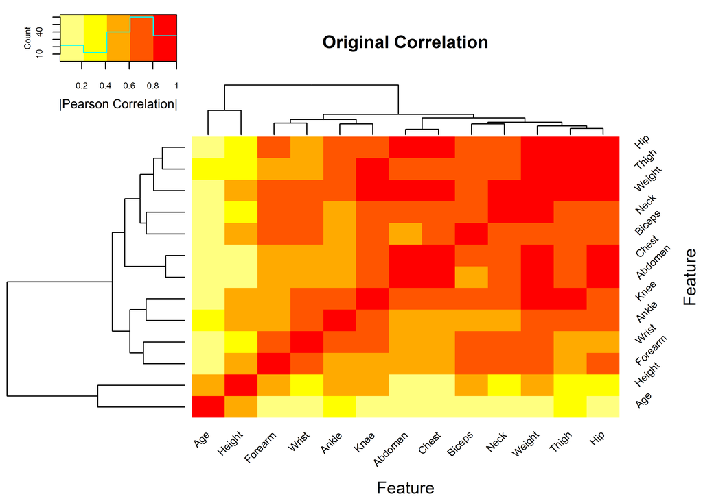

```r
par(op)
```

### 1.3.5 Decorrelating using ILAA

ILAA bootstrapped training and testing sets

```r
trainage_DE <- ILAA(trainingset,thr=thro,Outcome=outcome,verbose=TRUE)
```

fast | LM | Weight Age Weight Height Neck Chest Abdomen 0.07692308 1.00000000 0.15384615 0.53846154 0.84615385 0.76923077

Included: 13 , Uni p: 0.01153846 , Base Size: 1 , Rcrit: 0.1652337

1 <R=0.843,thr=0.900>, Top: 2< 1 >Fa= 2,<|><>Tot Used: 4 , Added: 2 , Zero Std: 0 , Max Cor: 0.898

2 <R=0.810,thr=0.800>, Top: 1< 5 >Fa= 2,<|><>Tot Used: 8 , Added: 5 , Zero Std: 0 , Max Cor: 0.747

3 <R=0.568,thr=0.700>, Top: 1< 1 >Fa= 2,<|><>Tot Used: 9 , Added: 1 , Zero Std: 0 , Max Cor: 0.611

4 <R=0.517,thr=0.600>, Top: 1< 1 >Fa= 2,<|><>Tot Used: 10 , Added: 1 , Zero Std: 0 , Max Cor: 0.594

5 <R=0.487,thr=0.500>, Top: 1< 1 >Fa= 2,<|><>Tot Used: 11 , Added: 1 , Zero Std: 0 , Max Cor: 0.487

6 <R=0.447,thr=0.400>, Top: 3< 1 >Fa= 4,<|><>Tot Used: 12 , Added: 4 , Zero Std: 0 , Max Cor: 0.384

7 <R=0.384,thr=0.400>

[ 7 ], 0.384463 Decor Dimension: 12 Nused: 12 . Cor to Base: 11 , ABase: 13 , Outcome Base: 0

```r
#trainage_DE <- ILAA(trainingset,thr=thro,Outcome=outcome,verbose=TRUE,bootstrap=30)

testage_DE <- predictDecorrelate(trainage_DE,testingset)
```

### 1.3.6 The Formulas

Generating the formulas

```r
theLaFormulas <- getLatentCoefficients(trainage_DE)

theCharformulas <- attr(theLaFormulas,"LatentCharFormulas")
pander::pander(as.matrix(theCharformulas))
```

| **La_Age** | + Age + (0.356)Weight - (1.395)Chest |
| --- | --- |
| **La_Neck** | - (0.069)Weight + Neck |
| **La_Chest** | - (0.255)Weight + Chest |
| **La_Abdomen** | - (0.123)Weight - (0.695)Chest + Abdomen |
| **La_Hip** | - (0.234)Weight + Hip |
| **La_Thigh** | - (0.029)Weight - (0.550)Hip + Thigh |
| **La_Knee** | - (0.072)Weight + Knee |
| **La_Ankle** | - (0.036)Weight + Ankle |
| **La_Biceps** | - (0.081)Weight + Biceps |
| **La_Forearm** | - (9.93e-03)Weight - (0.391)Biceps + Forearm |
| **La_Wrist** | - (0.024)Weight + Wrist |

### 1.3.7 Formulas Network

Displaying the features associations

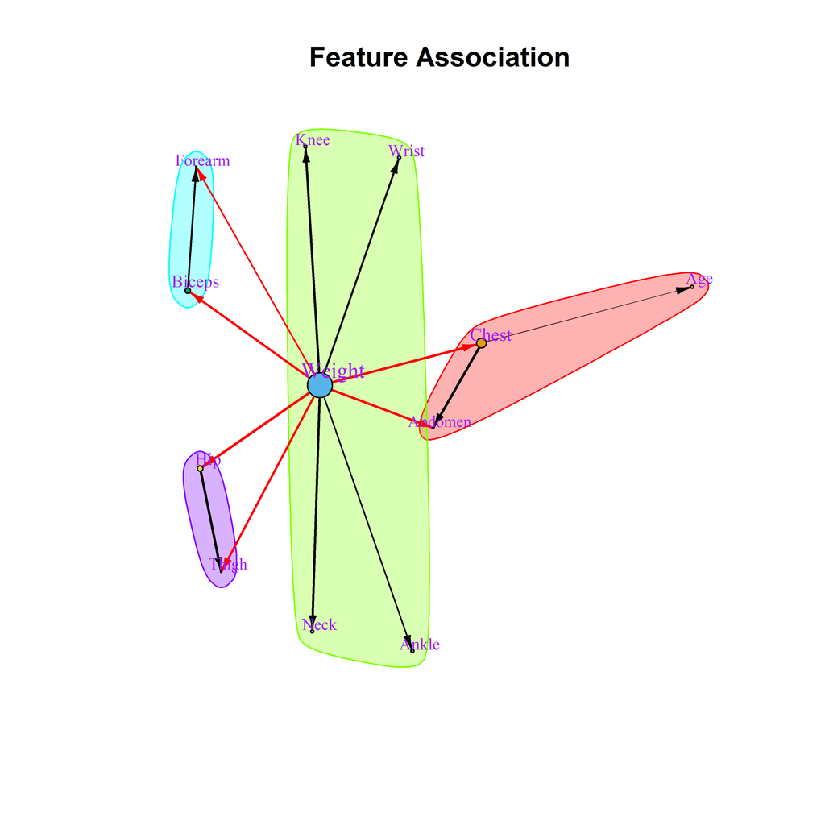

```r
par(op)

  transform <- attr(trainage_DE,"UPLTM") != 0
  colnames(transform) <- str_remove_all(colnames(transform),"La_")
  transform <- abs(transform*cor(trainingset[,rownames(transform)])) # The weights are proportional to the observed correlation


  VertexSize <- attr(trainage_DE,"fscore") # The size depends on the variable independence relevance (fscore)
  names(VertexSize) <- str_remove_all(names(VertexSize),"La_")
  VertexSize <- 0.5+9.5*(VertexSize-min(VertexSize))/(max(VertexSize)-min(VertexSize)) # Normalization
  VertexSize <- VertexSize[colnames(transform)]
  gr <- graph_from_adjacency_matrix(transform,mode = "directed",diag = FALSE,weighted=TRUE)
  gr$layout <- layout_with_fr

#  fc <- cluster_optimal(gr)
          fc <- cluster_walktrap (gr,steps=50)

  plot(fc, gr,
       edge.width = 2*E(gr)$weight,
       vertex.size=VertexSize,
       edge.arrow.size=0.5,
       edge.arrow.width=0.75,
       vertex.label.color="purple",
#       vertex.label.cex=0.85,
#       vertex.label.dist=1.2,
       vertex.label.cex=(0.70 + 0.025*VertexSize),
       vertex.label.dist=(0.5 + 0.05*VertexSize),


       main="Feature Association")
```

```r
par(op)

      varratios <- attr(trainage_DE,"VarRatio")
      names(varratios) <- str_remove_all(names(varratios),"La_")
      fscores <- attr(trainage_DE,"fscore")
      names(fscores) <- str_remove_all(names(fscores),"La_")
      clustable <- as.data.frame(cbind(Variable=fc$names,
                                       Formula=as.character(theCharformulas[paste("La_",fc$names,sep="")]),
                                       Cluster=fc$membership,
                                       ResidualVariance=round(varratios[fc$names],3),
                                       Fscore=round(fscores[fc$names],3)
                                       )
                                 )
      rownames(clustable) <- str_replace_all(rownames(clustable),"__","_")
      clustable$Variable <- NULL
      clustable$Cluster <- as.integer(clustable$Cluster)
      clustable$ResidualVariance <- as.numeric(clustable$ResidualVariance)
      clustable$Fscore <- as.numeric(clustable$Fscore)
      clustable <- clustable[order(-clustable$Fscore),]
      clustable <- clustable[order(-clustable$ResidualVariance),]
      clustable <- clustable[order(clustable$Cluster),]

pander::pander(as.matrix(clustable))
```

|  | Formula | Cluster | ResidualVariance | Fscore |
| --- | --- | --- | --- | --- |
| **Age** | + Age + (0.356)Weight - (1.395)Chest | 1 | 0.831 | -1 |
| **Chest** | - (0.255)Weight + Chest | 1 | 0.193 | 2 |
| **Abdomen** | - (0.123)Weight - (0.695)Chest + Abdomen | 1 | 0.133 | -2 |
| **Weight** | NA | 2 | 1.000 | 9 |
| **Ankle** | - (0.036)Weight + Ankle | 2 | 0.648 | -1 |
| **Wrist** | - (0.024)Weight + Wrist | 2 | 0.442 | -1 |
| **Neck** | - (0.069)Weight + Neck | 2 | 0.311 | -1 |
| **Knee** | - (0.072)Weight + Knee | 2 | 0.259 | -1 |
| **Forearm** | - (9.93e-03)Weight - (0.391)Biceps + Forearm | 3 | 0.511 | -2 |
| **Biceps** | - (0.081)Weight + Biceps | 3 | 0.347 | 0 |
| **Thigh** | - (0.029)Weight - (0.550)Hip + Thigh | 4 | 0.183 | -2 |
| **Hip** | - (0.234)Weight + Hip | 4 | 0.102 | 0 |

### 1.3.8 Correlation Matrix of the Data

The heat map of the ILAA transformed data

```r
par(op)

varlistDe <- colnames(trainage_DE)
varlistDe <- varlistDe[varlistDe != outcome]

  par(cex=0.6,cex.main=0.85,cex.axis=0.7)

# Training
  cormat <- cor(trainage_DE[,varlistDe],method="pearson")
  cormat[is.na(cormat)] <- 0
  gplots::heatmap.2(abs(cormat),
                    trace = "none",
                    mar = c(5,5),
                    col=rev(heat.colors(5)),
                    main = "Training: After ILAA Correlation",
                    cexRow = cexheat,
                    cexCol = cexheat,
                     srtCol=45,
                     srtRow=45,
                    key.title=NA,
                    key.xlab="|Pearson Correlation|",
                    xlab="Feature", ylab="Feature")
  diag(cormat) <- 0
  pander::pander(max(abs(cormat)))
```

*0.384*

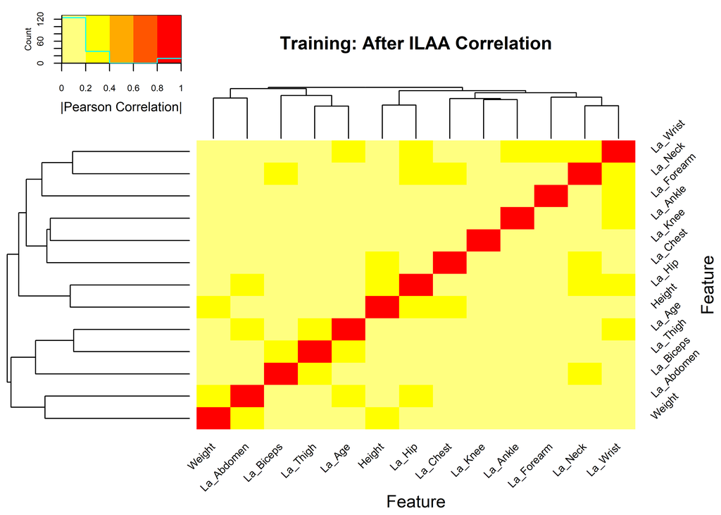

```r
  par(op)
```

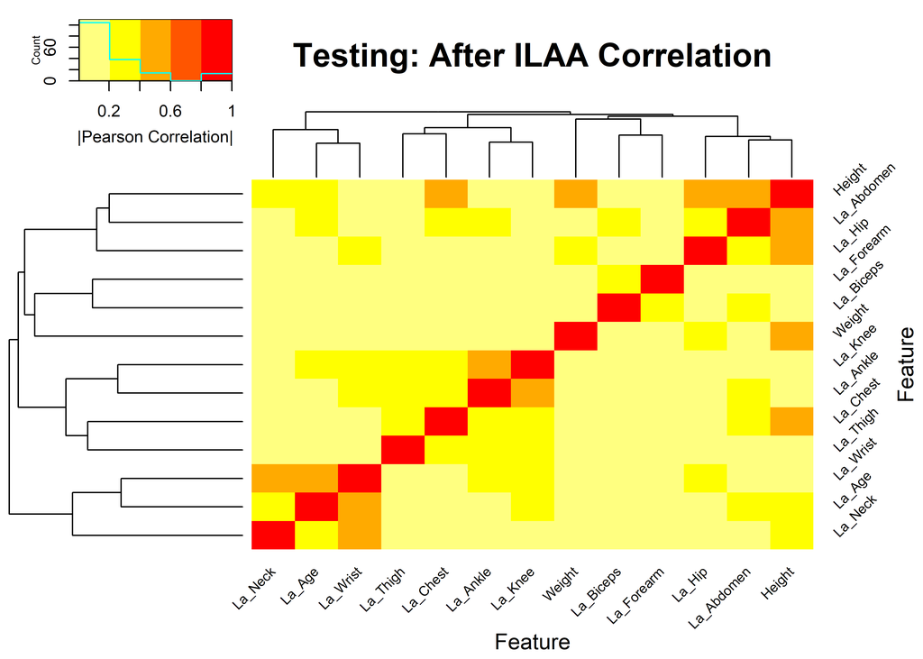

```r
# Testing

  cormat <- cor(testage_DE[,varlistDe],method="pearson")
  cormat[is.na(cormat)] <- 0
  gplots::heatmap.2(abs(cormat),
                    trace = "none",
                    mar = c(5,5),
                    col=rev(heat.colors(5)),
                    main = "Testing: After ILAA Correlation",
                    cexRow = cexheat,
                    cexCol = cexheat,
                     srtCol=45,
                     srtRow=45,
                    key.title=NA,
                    key.xlab="|Pearson Correlation|",
                    xlab="Feature", ylab="Feature")
```

```r
  diag(cormat) <- 0
  pander::pander(max(abs(cormat)))
```

*0.54*

```r
  par(op)
```

### 1.3.9 Modeling

#### 1.3.9.1 Modeling outcome using raw set

```r
outcomeModel <- LASSO_1SE(formula(paste(outcome,"~.")),trainingset);
predOutcome <- predict(outcomeModel,testingset)
pander::pander(as.matrix(outcomeModel$coef))
```

| **(Intercept)** | -23.4024 |
| --- | --- |
| **Age** | 0.0321 |
| **Height** | -0.0931 |
| **Abdomen** | 0.5748 |
| **Wrist** | -0.3093 |

#### 1.3.9.2 Modeling outcome using decorrelated set

```r
outcomeModel_DE <- LASSO_1SE(formula(paste(outcome,"~.")),trainage_DE);
predOutcome_DE <- predict(outcomeModel_DE,testage_DE)

pander::pander(as.matrix(outcomeModel_DE$coef),caption="ILAA Coef")
```

ILAA Coef

| **(Intercept)** | -26.0122 |
| --- | --- |
| **Weight** | 0.1265 |
| **La_Chest** | 0.4000 |
| **La_Abdomen** | 0.8502 |
| **La_Thigh** | 0.0252 |

```r
obsCoef <- getObservedCoef(trainage_DE,outcomeModel_DE)
pander::pander(as.matrix(obsCoef$coef),caption="ILAA Modeling")
```

ILAA Modeling

| **(Intercept)** | -26.0122 |
| --- | --- |
| **Weight** | -0.0810 |
| **Chest** | -0.1910 |
| **Abdomen** | 0.8502 |
| **Hip** | -0.0138 |
| **Thigh** | 0.0252 |

```r
pander::pander(cor.test(predOutcome,testingset[,outcome]),caption="Raw Model")
```

Raw Model

| Test statistic | df | P value | Alternative hypothesis | cor |
| --- | --- | --- | --- | --- |
| 12.2 | 61 | 5.09e-18 * * * | two.sided | 0.842 |

```r
pander::pander(cor.test(predOutcome_DE,testage_DE[,outcome]),caption="ILAA-based Model")
```

ILAA-based Model

| Test statistic | df | P value | Alternative hypothesis | cor |
| --- | --- | --- | --- | --- |
| 12.6 | 61 | 1.16e-18 * * * | two.sided | 0.85 |

#### 1.3.9.3 Univariate t-test

```r
rawunittvalues <- apply(as.matrix(testingset[,names(outcomeModel$coef)[-1]]),2,tvals,testingset[,outcome])
names(rawunittvalues) <- names(outcomeModel$coef)[-1]

deunittvalues <- apply(testage_DE[,names(outcomeModel_DE$coef)[-1]],2,tvals,testingset[,outcome])
```

#### 1.3.9.4 Comparing summaries

```r
psig <- 0.1/(ncol(testingset)-1)
lmod <- lm(paste(outcome,"~."),testingset[,c(outcome,names(outcomeModel$coef)[-1])])
try(vifx <-vif(lm(paste(outcome,"~."),testingset[,c(outcome,names(outcomeModel$coef)[-1])])))
sm <- summary(lmod)
if (length(lmod$coef)>10)
{
  sm$coefficients[1,4] <- 1.0
  gcoef <- lmod$coef[sm$coefficients[,4]<psig]
  lmod <- lm(paste(outcome,"~."),testingset[,c(outcome,names(gcoef))])
  try(vifx <-vif(lm(paste(outcome,"~."),testingset[,c(outcome,names(gcoef))])))
}



sm <- summary(lmod)
smcoef <- as.data.frame(sm$coefficients)
smcoef <- smcoef[order(-abs(smcoef[,3])),]
smcoef$Uni_t_values <- rawunittvalues[rownames(smcoef)]
if (!inherits(vif,"try-error")) smcoef$vif <-vifx[rownames(smcoef)]
smcoef <- smcoef[!is.na(smcoef$Uni_t_values),]
if (nrow(smcoef)>10) smcoef <- smcoef[smcoef[,4]<psig,]

pander::pander(smcoef)
```

|  | Estimate | Std. Error | t value | Pr(>\|t\|) | Uni_t_values | vif |
| --- | --- | --- | --- | --- | --- | --- |
| **Abdomen** | 0.7784 | 0.0633 | 12.301 | 8.37e-18 | 11.12 | 1.38 |
| **Height** | -0.6339 | 0.2766 | -2.292 | 2.56e-02 | -1.88 | 1.70 |
| **Wrist** | -1.9320 | 0.8755 | -2.207 | 3.13e-02 | 1.64 | 1.87 |
| **Age** | 0.0385 | 0.0549 | 0.701 | 4.86e-01 | 2.23 | 1.49 |

```r
pander::pander(t(c(R2=sm$r.squared,adj_R2=sm$adj.r.squared)))
```

| R2 | adj_R2 |
| --- | --- |
| 0.768 | 0.752 |

```r
pander::pander(c(numvar=nrow(smcoef)))
```

| numvar |
| --- |
| 4 |

```r
lmod_DE <- lm(paste(outcome,"~."),testage_DE[,c(outcome,names(outcomeModel_DE$coef)[-1])])
try(vifx <-vif(lm(paste(outcome,"~."),testage_DE[,c(outcome,names(outcomeModel_DE$coef)[-1])])))

sm <- summary(lmod_DE)
if (length(lmod_DE$coef)>10)
{
  sm$coefficients[1,4] <- 1.0
  gcoef <- lmod_DE$coef[sm$coefficients[,4]<psig]
  lmod_DE <- lm(paste(outcome,"~."),testage_DE[,c(outcome,names(gcoef))])
  try(vifx <-vif(lm(paste(outcome,"~."),testage_DE[,c(outcome,names(gcoef))])))
}

sm <- summary(lmod_DE)
lacoef <- as.data.frame(sm$coefficients)
lacoef <- lacoef[order(-abs(lacoef[,3])),]
lacoef$Uni_t_values <- deunittvalues[rownames(lacoef)]
if (!inherits(vifx,"try-error")) lacoef$vif <-vifx[rownames(lacoef)]
lacoef <- lacoef[!is.na(lacoef$Uni_t_values),]
if (nrow(lacoef)>10) lacoef <- lacoef[lacoef[,4]<psig,]

lacoef$formula <- theCharformulas[rownames(lacoef)]
lacoef$VarRatio <- varratios[str_remove_all(rownames(lacoef),"La_")]

pander::pander(lacoef)
```

|  | Estimate | Std. Error | t value | Pr(>\|t\|) | Uni_t_values | vif | formula | VarRatio |
| --- | --- | --- | --- | --- | --- | --- | --- | --- |
| **Weight** | 0.1570 | 0.0206 | 7.623 | 2.63e-10 | 4.88 | 1.00 | NA | 1.000 |
| **La_Abdomen** | 0.9196 | 0.1398 | 6.576 | 1.50e-08 | 5.62 | 1.10 | - (0.123)Weight - (0.695)Chest + Abdomen | 0.133 |
| **La_Chest** | 0.9209 | 0.1634 | 5.637 | 5.36e-07 | 5.34 | 1.22 | - (0.255)Weight + Chest | 0.193 |
| **La_Thigh** | -0.0345 | 0.2729 | -0.126 | 9.00e-01 | -1.79 | 1.14 | - (0.029)Weight - (0.550)Hip + Thigh | 0.183 |

```r
pander::pander(t(c(R2=sm$r.squared,adj_R2=sm$adj.r.squared)))
```

| R2 | adj_R2 |
| --- | --- |
| 0.755 | 0.738 |

```r
pander::pander(c(numvar=nrow(lacoef)))
```

| numvar |
| --- |
| 4 |

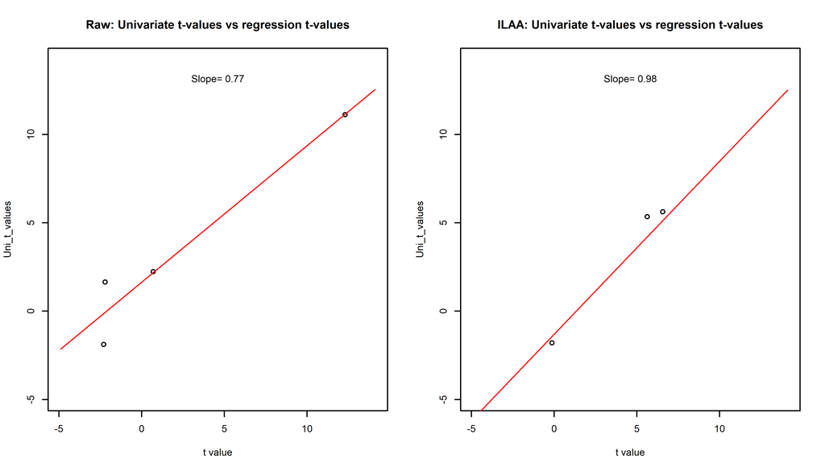

```r
xvals <-c(min(c(deunittvalues,rawunittvalues))-3,max(c(deunittvalues,rawunittvalues))+3)

par(mfrow=c(1,2),cex=0.5)

plot(smcoef[,c(3,5)],
     main="Raw: Univariate t-values vs regression t-values",
     xlim=xvals,
     ylim=xvals
     )

lmtvals <- lm(smcoef[,5]~smcoef[,3])
pred <- lmtvals$coefficients[1] + lmtvals$coefficients[2] * xvals
lines(x=xvals,y=pred,col="red")
text(xvals[1]+(xvals[2]-xvals[1])/2,xvals[2]-1,sprintf("Slope= %.2f",lmtvals$coefficients[2]))


plot(lacoef[-1,c(3,5)],
     main="ILAA: Univariate t-values vs regression t-values",
     xlim=xvals,
     ylim=xvals
     )

lmtvals <- lm(lacoef[,5]~lacoef[,3])
pred <- lmtvals$coefficients[1] + lmtvals$coefficients[2] * xvals
lines(x=xvals,y=pred,col="red")
text(xvals[1]+(xvals[2]-xvals[1])/2,xvals[2]-1,sprintf("Slope= %.2f",lmtvals$coefficients[2]))
```

```r
#pander::pander(summary(lmtvals))


pander::pander(cor.test(smcoef[,3],smcoef[,5]))
```

Pearson’s product-moment correlation: `smcoef[, 3]` and `smcoef[, 5]`

| Test statistic | df | P value | Alternative hypothesis | cor |
| --- | --- | --- | --- | --- |
| 5.35 | 2 | 0.0332 * | two.sided | 0.967 |

```r
pander::pander(cor.test(lacoef[,3],lacoef[,5]))
```

Pearson’s product-moment correlation: `lacoef[, 3]` and `lacoef[, 5]`

| Test statistic | df | P value | Alternative hypothesis | cor |
| --- | --- | --- | --- | --- |
| 4.6 | 2 | 0.0441 * | two.sided | 0.956 |

```r
par(op)
```

#### 1.3.9.5 Ploting predictions

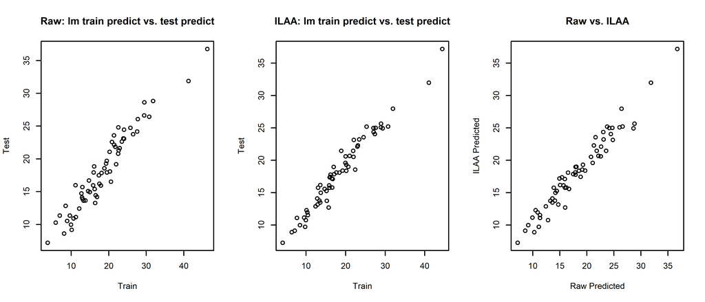

```r
par(mfrow=c(1,3),cex=0.5)
plot(lmod$fitted.values,predOutcome,main="Raw: lm train predict vs. test predict",xlab="Train",ylab="Test")
plot(lmod_DE$fitted.values,predOutcome_DE,main="ILAA: lm train predict vs. test predict",xlab="Train",ylab="Test")

plot(predOutcome,predOutcome_DE,xlab="Raw Predicted",ylab="ILAA Predicted",main="Raw vs. ILAA")
```

```r
par(op)
```

### 1.3.10 CV

#### 1.3.10.1 test Correlations

```r
par(op)
corresults <- CV_IDeA(dataframe,outcome,loops=loops)
```

………. ………. ………. ………. ………. ………. ………. ………. ………. ……….

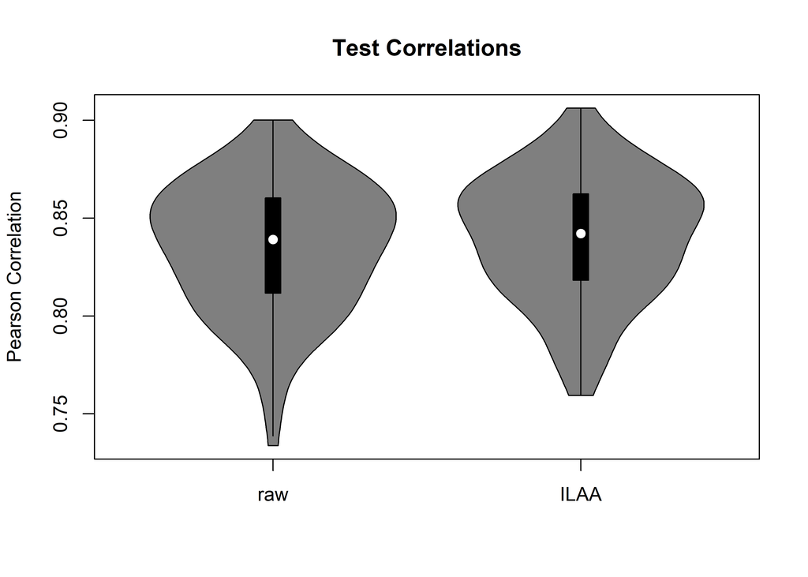

```r
mintvals <- min(c(min(corresults$rawtValues),min(corresults$detValues)))
maxvals <- max(c(max(corresults$rawtValues),max(corresults$detValues)))
xvals <- c(mintvals,maxvals)

vioplot(list(raw=corresults$testRawCorrelations,ILAA=corresults$testDeCorrelations),
        ylab="Pearson Correlation",
        main="Test Correlations")
```

```r
pander::pander(t.test(corresults$testDeCorrelations,corresults$testRawCorrelations,paired=TRUE))
```

Paired t-test: `corresults$testDeCorrelations` and `corresults$testRawCorrelations`

| Test statistic | df | P value | Alternative hypothesis | mean difference |
| --- | --- | --- | --- | --- |
| 3.37 | 99 | 0.00108 * * | two.sided | 0.0048 |

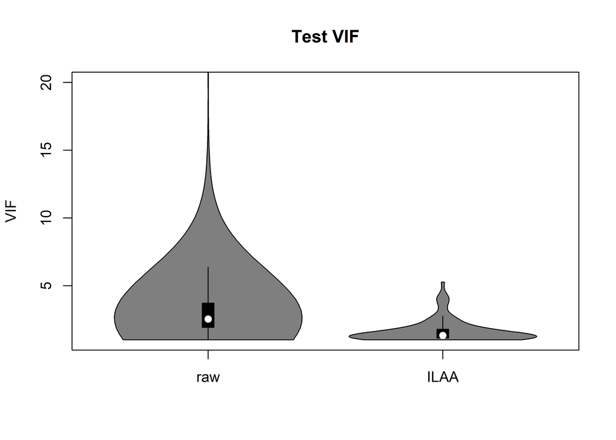

```r
sylim <- c(1,min(c(20,max(corresults$VIFRaw))))
vioplot(list(raw=corresults$VIFRaw,ILAA=corresults$VIFDe),
        ylab="VIF",
        ylim=sylim,
        main="Test VIF")
```

```r
pander::pander(summary(cbind(raw=corresults$VIFRaw,ILAA=corresults$VIFDe)))
```

| raw | ILAA |
| --- | --- |
| Min. : 1.000 | Min. :1.001 |
| 1st Qu.: 1.928 | 1st Qu.:1.131 |
| Median : 2.539 | Median :1.323 |
| Mean : 4.752 | Mean :1.642 |
| 3rd Qu.: 3.707 | 3rd Qu.:1.787 |
| Max. :43.687 | Max. :5.264 |

```r
summary(corresults$VIFRaw)
```

Min. 1st Qu. Median Mean 3rd Qu. Max. 1.000 1.928 2.539 4.752 3.707 43.687

### 1.3.11 The t-values

```r
par(op)
par(mfrow=c(1,2),cex=0.5)
plot(corresults$rawtValues,
     main="Raw: Univariate t-values vs Model t-values",
     xlab="Univariate",
     ylab="Model",
     xlim=xvals,
     ylim=xvals)

lmtvals <- lm(Model~.,corresults$rawtValues)
pred <- lmtvals$coefficients[1] + lmtvals$coefficients[2] * xvals
lines(x=xvals,y=pred,col="red")
text(xvals[1]+(xvals[2]-xvals[1])/2,xvals[2]-1,sprintf("Slope= %.2f",lmtvals$coefficients[2]))

pander::pander(summary(lmtvals))
```

|  | Estimate | Std. Error | t value | Pr(>\|t\|) |
| --- | --- | --- | --- | --- |
| **(Intercept)** | -2.122 | 0.146 | -14.6 | 3.46e-40 |
| **Uni** | 0.912 | 0.025 | 36.5 | 6.21e-141 |

Fitting linear model: Model ~ .

| Observations | Residual Std. Error | $R^2$ | Adjusted $R^2$ |
| --- | --- | --- | --- |
| 486 | 2.27 | 0.733 | 0.733 |

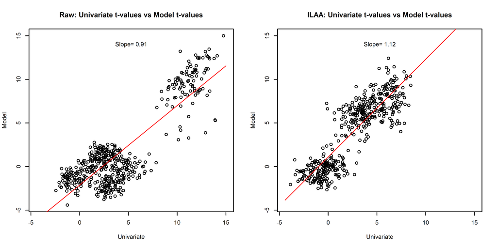

```r
plot(corresults$detValues,
      main="ILAA: Univariate t-values vs Model t-values",
     xlab="Univariate",
     ylab="Model",
     xlim=xvals,
     ylim=xvals)

lmtvals <- lm(Model~.,corresults$detValues)
pred <- lmtvals$coefficients[1] + lmtvals$coefficients[2] * xvals
lines(x=xvals,y=pred,col="red")
text(xvals[1]+(xvals[2]-xvals[1])/2,xvals[2]-1,sprintf("Slope= %.2f",lmtvals$coefficients[2]))
```

```r
pander::pander(summary(lmtvals))
```

|  | Estimate | Std. Error | t value | Pr(>\|t\|) |
| --- | --- | --- | --- | --- |
| **(Intercept)** | 1.09 | 0.1159 | 9.4 | 2.54e-19 |
| **Uni** | 1.12 | 0.0295 | 38.0 | 9.00e-144 |

Fitting linear model: Model ~ .

| Observations | Residual Std. Error | $R^2$ | Adjusted $R^2$ |
| --- | --- | --- | --- |
| 461 | 1.9 | 0.759 | 0.758 |

## 1.4 The Body Fat plots

Final plots

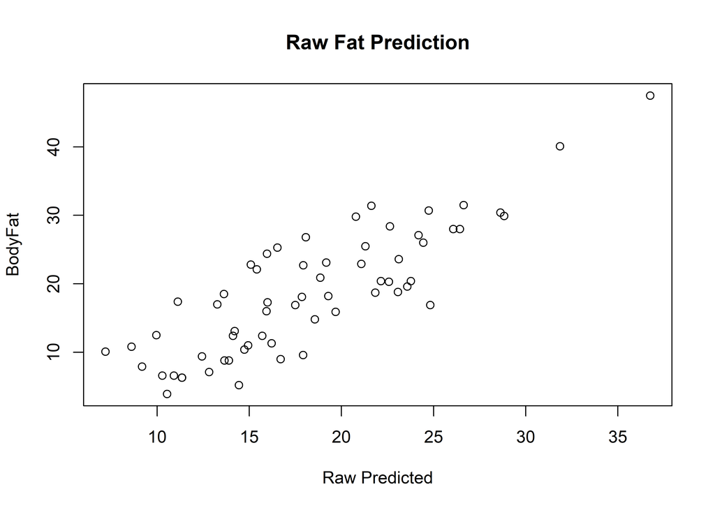

```r
plot(predOutcome,testingset[,outcome],xlab="Raw Predicted",ylab=outcome,main="Raw Fat Prediction")
```

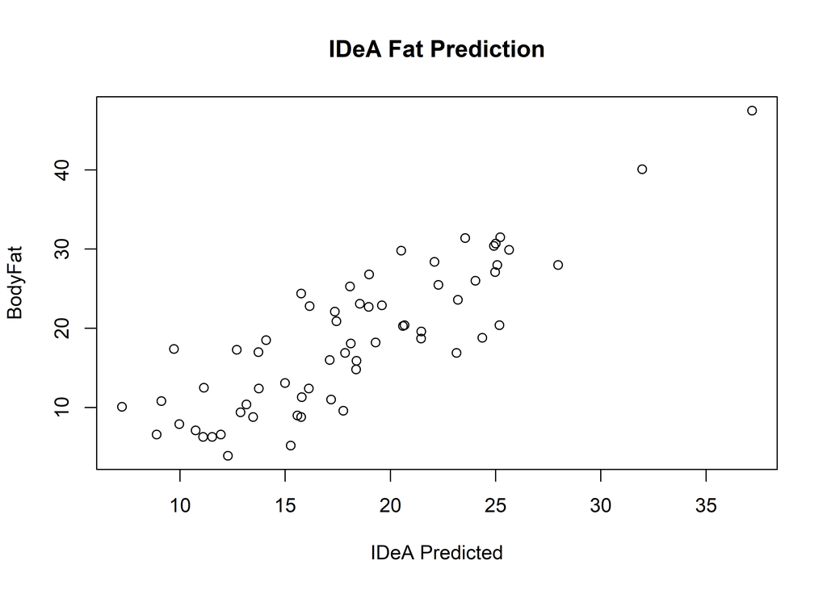

```r
plot(predOutcome_DE,testingset[,outcome],xlab="IDeA Predicted",ylab=outcome,main="IDeA Fat Prediction")
```